# Example document

Yours truly

Right here, right now

As Weiner et al. mentioned Weiner et al. (2018) …

$$\sum_{i=1}^n (x_i - x)^2$$

| table | with | pipes |
| --- | --- | --- |
| do it | with | R |

```r
summary(iris)
```

```
##   Sepal.Length    Sepal.Width     Petal.Length    Petal.Width          Species
##  Min.   :4.300   Min.   :2.000   Min.   :1.000   Min.   :0.100   setosa    :50
##  1st Qu.:5.100   1st Qu.:2.800   1st Qu.:1.600   1st Qu.:0.300   versicolor:50
##  Median :5.800   Median :3.000   Median :4.350   Median :1.300   virginica :50
##  Mean   :5.843   Mean   :3.057   Mean   :3.758   Mean   :1.199
##  3rd Qu.:6.400   3rd Qu.:3.300   3rd Qu.:5.100   3rd Qu.:1.800
##  Max.   :7.900   Max.   :4.400   Max.   :6.900   Max.   :2.500
```

# Water lilies analysis

There is a lake in a garden. Every day, the water lilies cover twice as much area as the previous day. On the first day, the water lilies cover 1/100th of the area of the lake.

What is the formula to calculate the area covered by the water lilies on day n? (pen and paper, not in Rstudio!)

$$A_n = A_{n-1} \cdot 2$$

$$A(n) = \frac{1}{100} \cdot 2^{n-1}$$
assign days 1 … 10 to variable x. Now assign the fraction of the area covered by water lilies on day n to variable y

```r
days <- 1:10
area <- 1/100 * 2^(days - 1)
```

plot x vs y (use the simple plot(x, y) function)

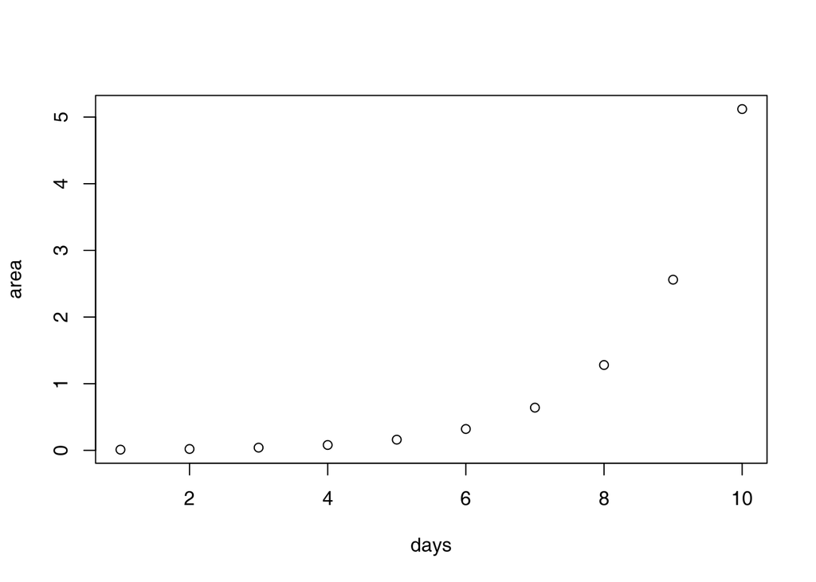

```r
plot(days, area)
```

When will the half of the area be covered by water lilies? Use abline(h=.5) (what does it do?) to show a graphical solution What is the fraction on day 3? Hint: what does y[3] do? Speaking of which, what dows y[4:5] do? (just try it!) Make the plot yourself. use ‘col’ parameter of plot and a color name (e.g. “red”) to change the color of the line (plot(…, col=“red”)) what if each day the lilies cover a fraction of area that is 1.5 the fraction of area on the previous day? Use lines(x, y) function to put a second line on the plot

Weiner, January, Jeroen Maertzdorf, Jayne S Sutherland, Fergal J Duffy, Ethan Thompson, Sara Suliman, Gayle McEwen, et al. 2018. “Metabolite Changes in Blood Predict the Onset of Tuberculosis.” *Nature Communications* 9 (1): 1–12.